# Dataset Exploration

## Preliminary Wrangling

> This data set includes information about individual rides made in a bike-sharing system covering the greater San Francisco Bay area.

```python
# import all packages and set plots to be embedded inline
import numpy as np
import pandas as pd
import matplotlib.pyplot as plt
import seaborn as sb
from matplotlib import pyplot

%matplotlib inline
```

> Loading dataset

```python
df= pd.read_csv(r"C:\Users\Anna-Lena\Downloads\201902-fordgobike-tripdata.csv")
df.head()
```

|  | duration_sec | start_time | end_time | start_station_id | start_station_name | start_station_latitude | start_station_longitude | end_station_id | end_station_name | end_station_latitude | end_station_longitude | bike_id | user_type | member_birth_year | member_gender | bike_share_for_all_trip |
| --- | --- | --- | --- | --- | --- | --- | --- | --- | --- | --- | --- | --- | --- | --- | --- | --- |
| 0 | 52185 | 2019-02-28 17:32:10.1450 | 2019-03-01 08:01:55.9750 | 21.0 | Montgomery St BART Station (Market St at 2nd St) | 37.789625 | -122.400811 | 13.0 | Commercial St at Montgomery St | 37.794231 | -122.402923 | 4902 | Customer | 1984.0 | Male | No |
| 1 | 42521 | 2019-02-28 18:53:21.7890 | 2019-03-01 06:42:03.0560 | 23.0 | The Embarcadero at Steuart St | 37.791464 | -122.391034 | 81.0 | Berry St at 4th St | 37.775880 | -122.393170 | 2535 | Customer | NaN | NaN | No |
| 2 | 61854 | 2019-02-28 12:13:13.2180 | 2019-03-01 05:24:08.1460 | 86.0 | Market St at Dolores St | 37.769305 | -122.426826 | 3.0 | Powell St BART Station (Market St at 4th St) | 37.786375 | -122.404904 | 5905 | Customer | 1972.0 | Male | No |
| 3 | 36490 | 2019-02-28 17:54:26.0100 | 2019-03-01 04:02:36.8420 | 375.0 | Grove St at Masonic Ave | 37.774836 | -122.446546 | 70.0 | Central Ave at Fell St | 37.773311 | -122.444293 | 6638 | Subscriber | 1989.0 | Other | No |
| 4 | 1585 | 2019-02-28 23:54:18.5490 | 2019-03-01 00:20:44.0740 | 7.0 | Frank H Ogawa Plaza | 37.804562 | -122.271738 | 222.0 | 10th Ave at E 15th St | 37.792714 | -122.248780 | 4898 | Subscriber | 1974.0 | Male | Yes |

```python
df.info()
```

```
<class 'pandas.core.frame.DataFrame'>
RangeIndex: 183412 entries, 0 to 183411
Data columns (total 16 columns):
 #   Column                   Non-Null Count   Dtype
---  ------                   --------------   -----
 0   duration_sec             183412 non-null  int64
 1   start_time               183412 non-null  object
 2   end_time                 183412 non-null  object
 3   start_station_id         183215 non-null  float64
 4   start_station_name       183215 non-null  object
 5   start_station_latitude   183412 non-null  float64
 6   start_station_longitude  183412 non-null  float64
 7   end_station_id           183215 non-null  float64
 8   end_station_name         183215 non-null  object
 9   end_station_latitude     183412 non-null  float64
 10  end_station_longitude    183412 non-null  float64
 11  bike_id                  183412 non-null  int64
 12  user_type                183412 non-null  object
 13  member_birth_year        175147 non-null  float64
 14  member_gender            175147 non-null  object
 15  bike_share_for_all_trip  183412 non-null  object
dtypes: float64(7), int64(2), object(7)
memory usage: 22.4+ MB
```

```python
df.head()
```

|  | duration_sec | start_time | end_time | start_station_id | start_station_name | start_station_latitude | start_station_longitude | end_station_id | end_station_name | end_station_latitude | end_station_longitude | bike_id | user_type | member_birth_year | member_gender | bike_share_for_all_trip |
| --- | --- | --- | --- | --- | --- | --- | --- | --- | --- | --- | --- | --- | --- | --- | --- | --- |
| 0 | 52185 | 2019-02-28 17:32:10.1450 | 2019-03-01 08:01:55.9750 | 21.0 | Montgomery St BART Station (Market St at 2nd St) | 37.789625 | -122.400811 | 13.0 | Commercial St at Montgomery St | 37.794231 | -122.402923 | 4902 | Customer | 1984.0 | Male | No |
| 1 | 42521 | 2019-02-28 18:53:21.7890 | 2019-03-01 06:42:03.0560 | 23.0 | The Embarcadero at Steuart St | 37.791464 | -122.391034 | 81.0 | Berry St at 4th St | 37.775880 | -122.393170 | 2535 | Customer | NaN | NaN | No |
| 2 | 61854 | 2019-02-28 12:13:13.2180 | 2019-03-01 05:24:08.1460 | 86.0 | Market St at Dolores St | 37.769305 | -122.426826 | 3.0 | Powell St BART Station (Market St at 4th St) | 37.786375 | -122.404904 | 5905 | Customer | 1972.0 | Male | No |
| 3 | 36490 | 2019-02-28 17:54:26.0100 | 2019-03-01 04:02:36.8420 | 375.0 | Grove St at Masonic Ave | 37.774836 | -122.446546 | 70.0 | Central Ave at Fell St | 37.773311 | -122.444293 | 6638 | Subscriber | 1989.0 | Other | No |
| 4 | 1585 | 2019-02-28 23:54:18.5490 | 2019-03-01 00:20:44.0740 | 7.0 | Frank H Ogawa Plaza | 37.804562 | -122.271738 | 222.0 | 10th Ave at E 15th St | 37.792714 | -122.248780 | 4898 | Subscriber | 1974.0 | Male | Yes |

```python
df.info()
```

```
<class 'pandas.core.frame.DataFrame'>
RangeIndex: 183412 entries, 0 to 183411
Data columns (total 16 columns):
 #   Column                   Non-Null Count   Dtype
---  ------                   --------------   -----
 0   duration_sec             183412 non-null  int64
 1   start_time               183412 non-null  object
 2   end_time                 183412 non-null  object
 3   start_station_id         183215 non-null  float64
 4   start_station_name       183215 non-null  object
 5   start_station_latitude   183412 non-null  float64
 6   start_station_longitude  183412 non-null  float64
 7   end_station_id           183215 non-null  float64
 8   end_station_name         183215 non-null  object
 9   end_station_latitude     183412 non-null  float64
 10  end_station_longitude    183412 non-null  float64
 11  bike_id                  183412 non-null  int64
 12  user_type                183412 non-null  object
 13  member_birth_year        175147 non-null  float64
 14  member_gender            175147 non-null  object
 15  bike_share_for_all_trip  183412 non-null  object
dtypes: float64(7), int64(2), object(7)
memory usage: 22.4+ MB
```

### What is/are the main feature(s) of interest in your dataset?

> The main features of this project are the duration, number of trips, days were the most trips are taken at the same time to see how the gorups of costumers compare with each other.

### What features in the dataset do you think will help support your investigation into your feature(s) of interest?

> This dataset has very interesting features that can help us investigate our matters. The first column that can help us is "duration_sec" from which we can extract the duration of the trip. On the other hand, "start_time" can help us find out the days where the most trips are done. The "user_type" can help us see how different groups of customers compare with each other. we would also want to know how the genders compare with each other and to help us do that is the "member_gender" column.

## Univariate Exploration

```python
df.info()
```

```
<class 'pandas.core.frame.DataFrame'>
RangeIndex: 183412 entries, 0 to 183411
Data columns (total 16 columns):
 #   Column                   Non-Null Count   Dtype
---  ------                   --------------   -----
 0   duration_sec             183412 non-null  int64
 1   start_time               183412 non-null  object
 2   end_time                 183412 non-null  object
 3   start_station_id         183215 non-null  float64
 4   start_station_name       183215 non-null  object
 5   start_station_latitude   183412 non-null  float64
 6   start_station_longitude  183412 non-null  float64
 7   end_station_id           183215 non-null  float64
 8   end_station_name         183215 non-null  object
 9   end_station_latitude     183412 non-null  float64
 10  end_station_longitude    183412 non-null  float64
 11  bike_id                  183412 non-null  int64
 12  user_type                183412 non-null  object
 13  member_birth_year        175147 non-null  float64
 14  member_gender            175147 non-null  object
 15  bike_share_for_all_trip  183412 non-null  object
dtypes: float64(7), int64(2), object(7)
memory usage: 22.4+ MB
```

```python
# Average trip duration in seconds
df.duration_sec.mean()
```

```
726.078435434977
```

##### Improving column readability

1. Converting the "df.duration_sec" to minutes
2. Rename "df.duration_sec" to "df.duration_min"
3. Rounding the numbers from the "duration_min" to two decimals.

```python
df.duration_sec= df.duration_sec / 60 # Converting the "df.duration_sec" to minutes
df.rename(columns={'duration_sec' : 'duration_min'},inplace=True) # Rename "df.duration_sec" to "df.duration_min"
df['duration_min']=df['duration_min'].apply(lambda x:round(x,2)) # Rounding the numbers from the "duration_min" to two decimals.
```

```python
# Average trip duration in minutes
df.duration_min.mean()
```

```
12.101300732776364
```

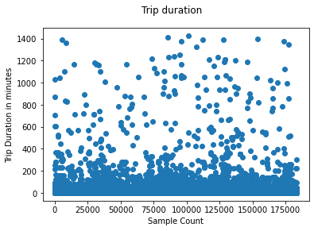

```python
plt.scatter(df.index, df['duration_min'])
plt.ylabel('Trip Duration in minutes')
plt.xlabel('Sample Count')
plt.suptitle('Trip duration')

plt.show()
```

#### Trip duration overview - Chart 1

> This plot shows the distribution of the data regarding the trip duration in minutes.

##### 2. Day of the trip

We want to explore in what day are the most trips taken. In order to do that we need to extraxt the day from "start_time" variable.

```python
 df.start_time #overview of the column
```

```
0         2019-02-28 17:32:10.1450
1         2019-02-28 18:53:21.7890
2         2019-02-28 12:13:13.2180
3         2019-02-28 17:54:26.0100
4         2019-02-28 23:54:18.5490
                    ...
183407    2019-02-01 00:04:49.7240
183408    2019-02-01 00:05:34.7440
183409    2019-02-01 00:06:05.5490
183410    2019-02-01 00:05:34.3600
183411    2019-02-01 00:00:20.6360
Name: start_time, Length: 183412, dtype: object
```

```python
df['day_of_trip'] = pd.DatetimeIndex(df['start_time']).day # extracting the day from "start_time" variable.
```

```python
df = df.replace({'day_of_trip': [1,8,15,22]}, 'monday')
df = df.replace({'day_of_trip': [2,9,16,23]}, 'tuesday')
df = df.replace({'day_of_trip': [3,10,17,24]}, 'wednesday')
df = df.replace({'day_of_trip': [4,11,18,25]}, 'thursday')
df = df.replace({'day_of_trip': [5,12,19,26]}, 'friday')
df = df.replace({'day_of_trip': [6,13,20,27]}, 'saturday')
df = df.replace({'day_of_trip': [7,14,21,28]}, 'sunday')

#1,8,15,22 = "monday"
#2,9,16,23 = "tuesday"
#3,10,17,24 = "wednesday"
#4,11,18,25 = "thursday"
#5,12,19,26 = "friday"
#6,13,20,27 = "saturday"
#7,14,21,28 = "sunday
```

```python
df.day_of_trip.unique()
```

```
array(['sunday', 'saturday', 'friday', 'thursday', 'wednesday', 'tuesday',
       'monday'], dtype=object)
```

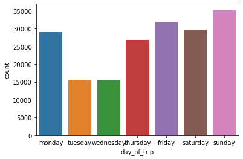

```python
sb.countplot(data=df, x='day_of_trip',order=["monday", "tuesday","wednesday","thursday","friday","saturday","sunday"]);
```

#### Day of trip - Chart 2

> In the barchart above we have an owerview of the days where the trips found place. Further we want to analyse if these results change when we compared to different costumer types and in gender comparison.

```python
df.user_type.value_counts(normalize=True)
```

```
Subscriber    0.891676
Customer      0.108324
Name: user_type, dtype: float64
```

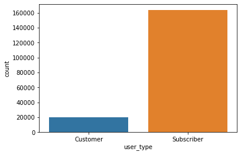

```python
sb.countplot(data=df, x='user_type');
```

#### Type of user - Chart 3

> Both value_counts and the barplot show as the we have alot more subcribers (89 %) compared to other costumers (11%). Moreover, we want to see if being in a certain costumers has and effect on trip duration and in what days the trips are taken.

```python
df.member_gender.value_counts(normalize=True)
```

```
Male      0.745951
Female    0.233198
Other     0.020851
Name: member_gender, dtype: float64
```

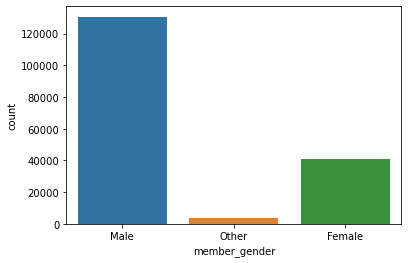

```python
sb.countplot(data=df, x='member_gender');
```

#### Gender distribution - Chart 4

> In this plot we clearly see that there are alot more users that are male (74%) compared to female (23%) and other (2%). In the next step we want to see how do they compare to each other when it comes to trip duration and in what days they take the trip.

### Discuss the distribution(s) of your variable(s) of interest. Were there any unusual points? Did you need to perform any transformations?

###### Trip duration

At this point we see that the average trip 12.10 minutes. As initialy the data was stored in seconds, we converted the variable in minutes to make it easier to understand.

###### User types

The analyses show tha we have alot more subcribers (89 %) compared to other costumers (11%).

##### Gender

From the result of the descriptive analyses we see that 74 % of users are male, 23% female and 2% other.

### Of the features you investigated, were there any unusual distributions? Did you perform any operations on the data to tidy, adjust, or change the form of the data? If so, why did you do this?

One thing that was unexpected to see that there is a big difference between genders and the fact there are almost 90% of the users that are subscribers was unusual.

Knowing that in these kind of bussines models seconds are used to count how much the user has to pay for a trip it was expected to see the data stored in seconds. However to make our analyses easier we converted the data in minutes. On the other hand, to get through with our point of interes "Day of the Trip" we had to extraxt the day from the "start_trip" variable and then to make it easier to read we changed the form of the data from numbers in to weekdays names.

## Bivariate Exploration

> In this section, investigate relationships between pairs of variables in your data. Make sure the variables that you cover here have been introduced in some fashion in the previous section (univariate exploration).

### 1. Trip duration by user type

```python
df.groupby('user_type').mean().duration_min,
```

```
(user_type
 Customer      23.874411
 Subscriber    10.671055
 Name: duration_min, dtype: float64,)
```

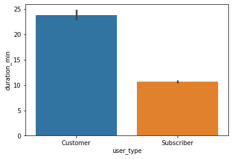

```python
ax = sns.barplot(x="user_type", y="duration_min", data=df)
```

##### Relation between trip duration & user type Chart - 5

In the this chart we see that on average customers have higher average (23.8 min) compared to subscribers (10.6 min).

### 2. Day of trip by user type

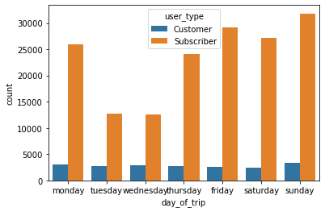

```python
sb.countplot(data=df, x='day_of_trip', hue='user_type', order=["monday", "tuesday","wednesday","thursday","friday","saturday","sunday"]);
```

##### Relation between user type and the day of trip - Chart 6

The chart show that costumeres group are very stable in taking trips in every day of the week. On the other hand, in the subscribers group we see a higher number of trips on monday, friday and in the weekend.

### Gender analyses

```python
df.groupby('member_gender').mean().duration_min,
```

```
(member_gender
 Female    12.984508
 Male      11.210645
 Other     16.608535
 Name: duration_min, dtype: float64,)
```

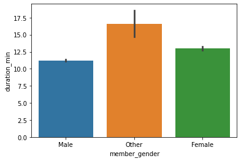

```python
ax = sns.barplot(x="member_gender", y="duration_min", data=df)
```

##### Trip duration by gender - Chart 7

The chart above show the differences in average trip duration between different genders.

### Talk about some of the relationships you observed in this part of the investigation. How did the feature(s) of interest vary with other features in the dataset?

##### Relation between trip duration & user type

For this feature of interest we see that on average customers have higher average (23.8 min) compared to subscribers (10.6 min). But when we assume that the answer to this difference is that people in the subscribers group use the bikes for daily duties inside the city and take shorter trips as for the costumers group who may use them more for recreation purpouses.

###### Relation between user type and the day of trip

Our data shows that costumeres group are very stable in taking trips in every day of the week. On the other hand, in the subscribers group we see a higher number of trips on monday, friday and in the weekend.

##### Gender Analyses

In this case we don't see a big difference between Male (11.2 min.) and Female (12.9 min.) but the "other" gender group has an average of 16.6 min per trip. Considering that the gender group "other" represent only 2% of all individuals we have to interpret this finding with caution.

## Multivariate Exploration

> Create plots of three or more variables to investigate your data even further. Make sure that your investigations are justified, and follow from your work in the previous sections.

#### 1. Trip duration by trip day & type of user

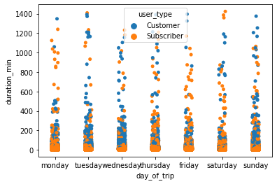

```python
ax = sns.stripplot(x="day_of_trip", y="duration_min", hue="user_type", data=df, order=["monday", "tuesday","wednesday","thursday","friday","saturday","sunday"])
```

The chart above show the differences in trip duration in different day of the week between different user types.

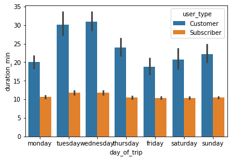

```python
ax = sns.barplot(x="day_of_trip", y="duration_min", hue="user_type", data=df, order=["monday", "tuesday","wednesday","thursday","friday","saturday","sunday"])
```

##### Trip duration by day of the week - Chart 9

The bartchart above is another way of presenting the differences in trip duration in different day of the week between different user types.

##### Age analyses

```python
df["age"]= 2019 - df["member_birth_year"]
```

```python
df = df.drop(df[df['age'] > 100].index)
```

```python
df.age.mean()
```

```
34.158777666714265
```

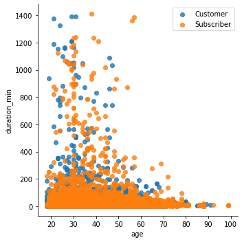

```python
sns.lmplot( x="age", y="duration_min", data=df, fit_reg=False, hue='user_type', legend=False)

# Move the legend to an empty part of the plot
plt.legend(loc='upper right')

plt.show()
```

##### Trip duration by age and user type - Chart 10

The sccaterplot shows the relation that age has with the trip duration.

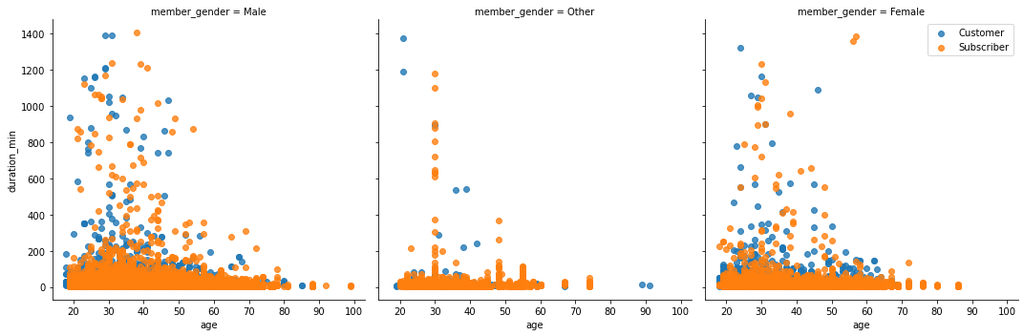

```python
sns.lmplot( x="age", y="duration_min", data=df, fit_reg=False, hue='user_type', col="member_gender", legend=False)

# Move the legend to an empty part of the plot
plt.legend(loc='upper right')

plt.show()
```

##### Trip duration by age and user type - Chart 11

The sccaterplots above shows the relation that age and gender has with the trip duration.

```python
df.groupby('day_of_trip').mean().age
```

```
day_of_trip
friday       34.415673
monday       34.439147
saturday     34.414765
sunday       34.496620
thursday     34.201285
tuesday      33.119399
wednesday    32.755784
Name: age, dtype: float64
```

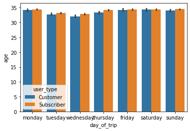

```python
ax = sns.barplot(x="day_of_trip", y="age", hue="user_type", data=df, order=["monday", "tuesday","wednesday","thursday","friday","saturday","sunday"])
```

##### Day of trip by age and user type - Chart 12

The barplot above show the average age per day of trip.

### Talk about some of the relationships you observed in this part of the investigation. Were there features that strengthened each other in terms of looking at your feature(s) of interest?

> In the last graph, we did calculate the age of the members, and then it was very interesting to see if age has an impact on trip duration. As we see in the graph above after the age of 60 the duration of the trip starts to decrease. Were there any interesting or surprising interactions between features?

### Were there any interesting or surprising interactions between features?

> In the graph 11, it was surprising to see that in the female category the decrease in the trip duration starts at an earlier age compared to males.

> Then in the last barplot we see that on average individuals who take trips on tuesday and wednesday are slightly younger (1 to 2 years on average) compared to rest.

```python
df.to_csv('fordgobike-tripdata2.csv')
```

> At the end of your report, make sure that you export the notebook as an html file from the `File > Download as... > HTML` menu. Make sure you keep track of where the exported file goes, so you can put it in the same folder as this notebook for project submission. Also, make sure you remove all of the quote-formatted guide notes like this one before you finish your report!